# Estatística Aplicada

[figure not shown]

```r
library(haven)
library(dplyr)
library(magrittr)
library(ggplot2)
library(gridExtra)
library(tidyr)
```

# Base de dados

```r
base <-
  read_sav("BancoTeseCris_09_07_2013.sav") %>%
  mutate(
    Sexo = factor(Sexo, labels = c("Homem", "Mulher"))
  )
```

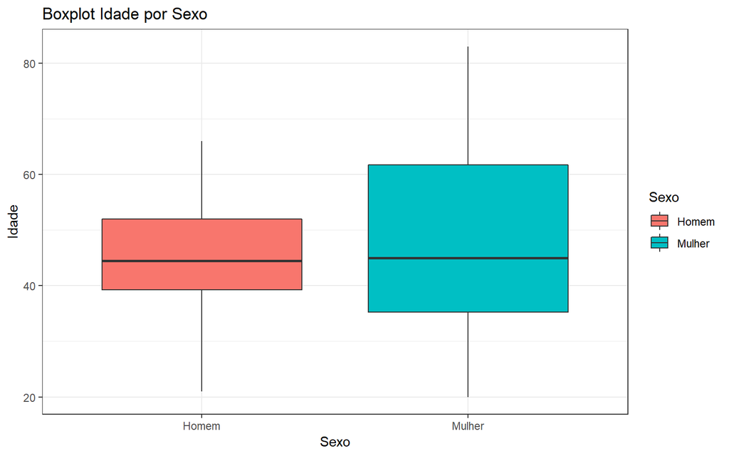

```r
# Visualizacao sexo por idade
base %>%
  select(Sexo, Idade) %>%
  na.omit() %>%
  ggplot(aes(x=Sexo, y=Idade, fill = Sexo)) +
  geom_boxplot() +
  labs(x = "Sexo", title = "Boxplot Idade por Sexo") +
  theme_bw()
```

# PEW

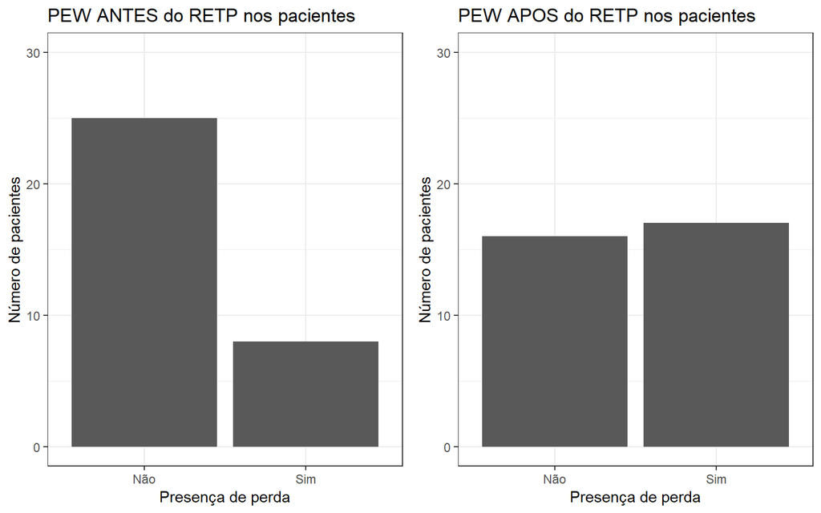

```r
base_pew <-
  base %>%
  select(
    Sexo, Idade,
    PEW_ANTES, PEW_APOS
  ) %>%
  na.omit() %>%
  # Perda no PEW (2 = teve perda)
  mutate(
    PEW_ANTES = factor(PEW_ANTES, labels = c("Não", "Sim")),
    PEW_APOS = factor(PEW_APOS, labels = c("Não", "Sim"))
  )

# Visualizacao PEW ANTES
graf_pew_antes <-
  base_pew$PEW_ANTES %>% table() %>% as_tibble() %>%
  ggplot() +
  geom_bar(aes(x=., y=n), stat = "identity") +
  theme_bw() +
  labs(x = "Presença de perda", y = "Número de pacientes", title = "PEW ANTES do RETP nos pacientes") +
  scale_y_continuous(limits = c(0, 30))

# Visualizacao PEW APOS
graf_pew_apos <-
  base_pew$PEW_APOS %>% table() %>% as_tibble() %>%
  ggplot() +
  geom_bar(aes(x=., y=n), stat = "identity") +
  theme_bw() +
  labs(x = "Presença de perda", y = "Número de pacientes", title = "PEW APOS do RETP nos pacientes") +
  scale_y_continuous(limits = c(0, 30))

grid.arrange(graf_pew_antes, graf_pew_apos, ncol = 2)
```

Em geral, com base no gráfico, parece que houve perda no PEW após o RETP.

## Teste de Hipótese

```r
# Hipotese: O estudo teve efeito sobre o PEW?

# H0: Não teve diferença
# H1: Teve dirença

base_pew %>%
  select(PEW_ANTES, PEW_APOS) %>%
  table() %>%
  mcnemar.test()
```

```
##
##  McNemar's Chi-squared test with continuity correction
##
## data:  .
## McNemar's chi-squared = 4.9231, df = 1, p-value = 0.0265
```

Com base num nivel de significancia de 5% rejeitamos a hipotese nula, ou seja, há evidencias de que teve diferença entre as variaveis.

# Inflamação

Marcadores de Inflamacao: * TNFa01, TNFa02 * ICAM1, ICAM2 * PCR01, PCR02 * IL601, IL602 * VCAM1, VCAM2

## TNFa

### Análise Descritiva

```r
base_tnf <-
  base %>%
  select(TNFa01, TNFa02) %>%
  na.omit()

base_tnf %>% summary()
```

```
##      TNFa01          TNFa02
##  Min.   :20.68   Min.   :20.67
##  1st Qu.:20.87   1st Qu.:20.81
##  Median :21.08   Median :21.49
##  Mean   :25.67   Mean   :24.27
##  3rd Qu.:30.78   3rd Qu.:24.78
##  Max.   :40.06   Max.   :64.94
```

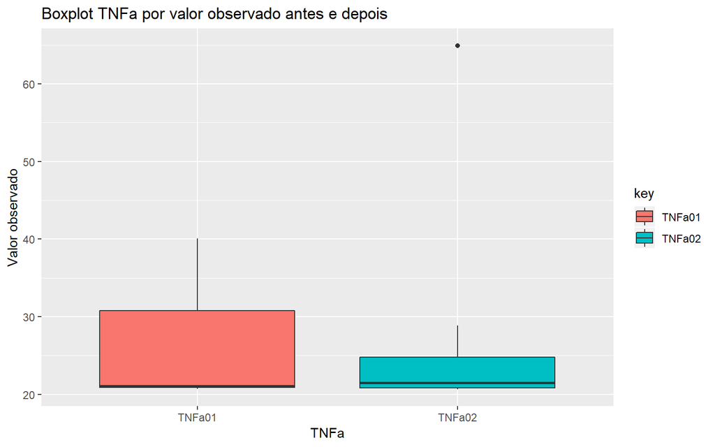

```r
base_tnf %>%
  gather() %>%
  ggplot(aes(x = key, y = value, fill = key)) +
  geom_boxplot() +
  labs(x = "TNFa", y = "Valor observado", title = "Boxplot TNFa por valor observado antes e depois")
```

Em geral, com base no gráfico, parece que houve uma redução no TNFa após o RETP.

### Teste de Hipóstese

```r
# Normalidade: TNFa antes
shapiro.test(base_tnf$TNFa01)
```

```
##
##  Shapiro-Wilk normality test
##
## data:  base_tnf$TNFa01
## W = 0.7572, p-value = 3.58e-05
```

Com base num nivel de significancia de 5%, rejeitamos a hipótese de normalidade para a variavel.

```r
# Normalidade: TNFa depois
shapiro.test(base_tnf$TNFa02)
```

```
##
##  Shapiro-Wilk normality test
##
## data:  base_tnf$TNFa02
## W = 0.41291, p-value = 3.727e-09
```

Com base num nivel de significancia de 5%, rejeitamos a hipótese de normalidade para a variavel.

`Considerando normalidade mesmo não sendo normal`

#### Teste de Hipotese sobre a média para variâncias desconhecidas

H0: mu1 = mu2 H1: mu1 =/= mu2

```r
t.test(base_tnf$TNFa01, base_tnf$TNFa02, alternative = "two.sided", paired = T)
```

```
##
##  Paired t-test
##
## data:  base_tnf$TNFa01 and base_tnf$TNFa02
## t = 0.72094, df = 25, p-value = 0.4776
## alternative hypothesis: true difference in means is not equal to 0
## 95 percent confidence interval:
##  -2.601299  5.403329
## sample estimates:
## mean of the differences
##                1.401015
```

Com base num nível de significância de 5%, não rejeitamos a hipótese nula, ou seja, há evidências de que a média da variável TNFa antes é igual a média da variável TNFa depois.

## ICAM

### Análise Descritiva

```r
base_icam <-
  base %>%
  select(ICAM1, ICAM2) %>%
  na.omit()

base_icam %>% summary()
```

```
##      ICAM1            ICAM2
##  Min.   : 254.5   Min.   : 128.2
##  1st Qu.:1326.4   1st Qu.: 458.0
##  Median :1934.1   Median :1571.2
##  Mean   :2205.0   Mean   :1653.1
##  3rd Qu.:2695.6   3rd Qu.:2282.4
##  Max.   :5392.3   Max.   :3550.1
```

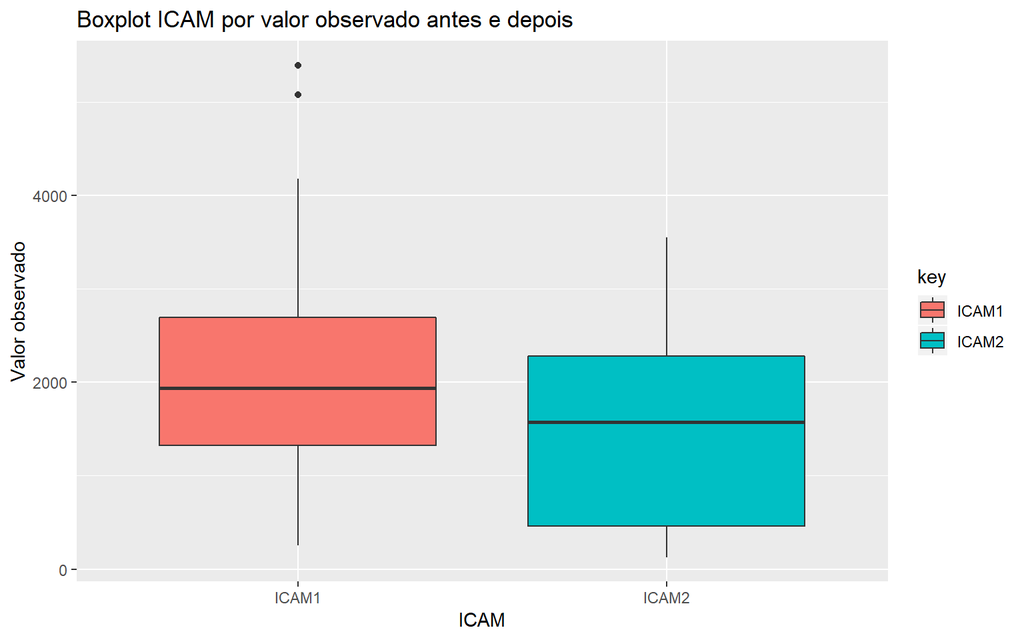

```r
base_icam %>%
  gather() %>%
  ggplot(aes(x = key, y = value, fill = key)) +
  geom_boxplot() +
  labs(x = "ICAM", y = "Valor observado", title = "Boxplot ICAM por valor observado antes e depois")
```

Em geral, com base no gráfico, parece que houve uma redução no ICAM após o RETP.

### Teste de Hipóstese

```r
# Normalidade: ICAM antes
shapiro.test(base_icam$ICAM1)
```

```
##
##  Shapiro-Wilk normality test
##
## data:  base_icam$ICAM1
## W = 0.91828, p-value = 0.0918
```

Com base num nivel de significancia de 5%, não rejeitamos a hipótese de normalidade para a variavel.

```r
# Normalidade: ICAM depois
shapiro.test(base_icam$ICAM2)
```

```
##
##  Shapiro-Wilk normality test
##
## data:  base_icam$ICAM2
## W = 0.88456, p-value = 0.02139
```

Com base num nivel de significancia de 5%, rejeitamos a hipótese de normalidade para a variavel.

`Considerando normalidade mesmo não sendo normal`

#### Teste de Hipotese sobre a média para variâncias desconhecidas

H0: mu1 = mu2 H1: mu1 =/= mu2

```r
t.test(base_icam$ICAM1, base_icam$ICAM2, alternative = "two.sided", paired = T)
```

```
##
##  Paired t-test
##
## data:  base_icam$ICAM1 and base_icam$ICAM2
## t = 2.1425, df = 19, p-value = 0.04532
## alternative hypothesis: true difference in means is not equal to 0
## 95 percent confidence interval:
##    12.7344 1091.0376
## sample estimates:
## mean of the differences
##                 551.886
```

Com base num nível de significância de 5%, rejeitamos a hipótese nula, ou seja, há evidências de que a média da variável ICAM antes é diferente da média da variável ICAM depois.

## PCR

### Análise Descritiva

```r
base_pcr <-
  base %>%
  select(PCR01, PCR02) %>%
  na.omit()

base_pcr %>% summary()
```

```
##      PCR01            PCR02
##  Min.   :0.4748   Min.   :0.2234
##  1st Qu.:1.7259   1st Qu.:1.2891
##  Median :2.6950   Median :1.9652
##  Mean   :2.3228   Mean   :1.6826
##  3rd Qu.:3.0130   3rd Qu.:2.0794
##  Max.   :3.3695   Max.   :2.1753
```

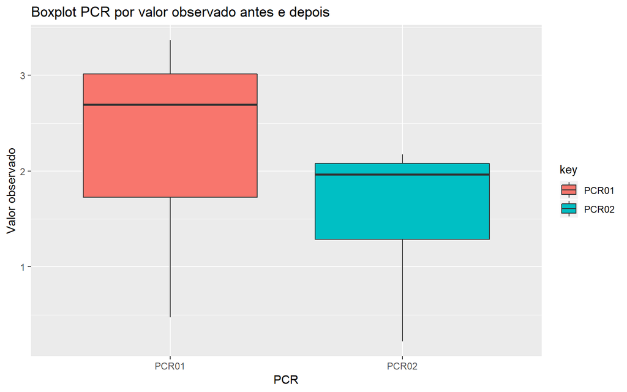

```r
base_pcr %>%
  gather() %>%
  ggplot(aes(x = key, y = value, fill = key)) +
  geom_boxplot() +
  labs(x = "PCR", y = "Valor observado", title = "Boxplot PCR por valor observado antes e depois")
```

Em geral, com base no gráfico, parece que houve uma redução no PCR após o RETP.

### Teste de Hipóstese

```r
# Normalidade: PCR antes
shapiro.test(base_pcr$PCR01)
```

```
##
##  Shapiro-Wilk normality test
##
## data:  base_pcr$PCR01
## W = 0.86818, p-value = 0.0004309
```

Com base num nivel de significancia de 5%, rejeitamos a hipótese de normalidade para a variavel.

```r
# Normalidade: PCR depois
shapiro.test(base_pcr$PCR02)
```

```
##
##  Shapiro-Wilk normality test
##
## data:  base_pcr$PCR02
## W = 0.71969, p-value = 4.498e-07
```

Com base num nivel de significancia de 5%, rejeitamos a hipótese de normalidade para a variavel.

`Considerando normalidade mesmo não sendo normal`

#### Teste de Hipotese sobre a média para variâncias desconhecidas

H0: mu1 = mu2 H1: mu1 =/= mu2

```r
t.test(base_pcr$PCR01, base_pcr$PCR02, alternative = "two.sided", paired = T)
```

```
##
##  Paired t-test
##
## data:  base_pcr$PCR01 and base_pcr$PCR02
## t = 6.6193, df = 36, p-value = 1.042e-07
## alternative hypothesis: true difference in means is not equal to 0
## 95 percent confidence interval:
##  0.4440705 0.8363889
## sample estimates:
## mean of the differences
##               0.6402297
```

Com base num nível de significância de 5%, rejeitamos a hipótese nula, ou seja, há evidências de que a média da variável PCR antes é diferente da média da variável PCR depois.

## IL-6

### Análise Descritiva

```r
base_il6 <-
  base %>%
  select(IL601, IL602) %>%
  na.omit()

base_il6 %>% summary()
```

```
##      IL601           IL602
##  Min.   :62.82   Min.   :42.54
##  1st Qu.:75.73   1st Qu.:78.70
##  Median :79.36   Median :80.79
##  Mean   :81.29   Mean   :78.68
##  3rd Qu.:89.04   3rd Qu.:83.71
##  Max.   :99.72   Max.   :91.00
```

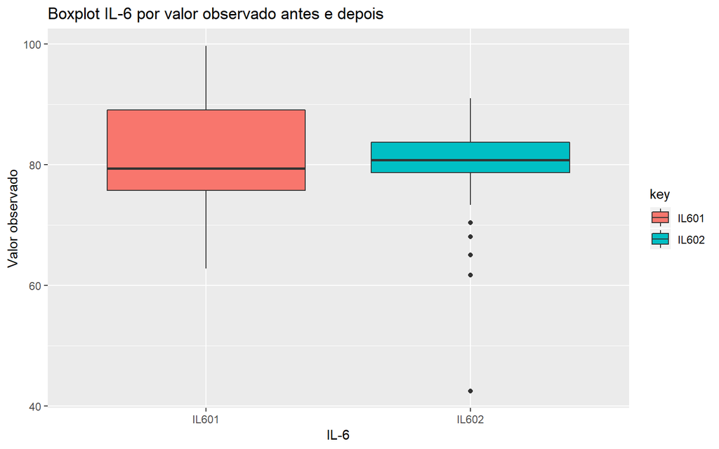

```r
base_il6 %>%
  gather() %>%
  ggplot(aes(x = key, y = value, fill = key)) +
  geom_boxplot() +
  labs(x = "IL-6", y = "Valor observado", title = "Boxplot IL-6 por valor observado antes e depois")
```

Em geral, com base no gráfico, parece que houve uma redução no IL-6 após o RETP.

### Teste de Hipóstese

```r
# Normalidade: IL-6 antes
shapiro.test(base_il6$IL601)
```

```
##
##  Shapiro-Wilk normality test
##
## data:  base_il6$IL601
## W = 0.98053, p-value = 0.8851
```

Com base num nivel de significancia de 5%, não rejeitamos a hipótese de normalidade para a variavel.

```r
# Normalidade: IL-6 depois
shapiro.test(base_il6$IL602)
```

```
##
##  Shapiro-Wilk normality test
##
## data:  base_il6$IL602
## W = 0.82518, p-value = 0.0004873
```

Com base num nivel de significancia de 5%, rejeitamos a hipótese de normalidade para a variavel.

`Considerando normalidade mesmo não sendo normal`

#### Teste de Hipotese sobre a média para variâncias desconhecidas

H0: mu1 = mu2 H1: mu1 =/= mu2

```r
t.test(base_il6$IL601, base_il6$IL602, alternative = "two.sided", paired = T)
```

```
##
##  Paired t-test
##
## data:  base_il6$IL601 and base_il6$IL602
## t = 0.85086, df = 25, p-value = 0.4029
## alternative hypothesis: true difference in means is not equal to 0
## 95 percent confidence interval:
##  -3.699977  8.909266
## sample estimates:
## mean of the differences
##                2.604645
```

Com base num nível de significância de 5%, não rejeitamos a hipótese nula, ou seja, há evidências de que a média da variável IL-6 antes não é diferente da média da variável IL-6 depois.

## VCAM

### Análise Descritiva

```r
base_vcam <-
  base %>%
  select(VCAM1, VCAM2) %>%
  na.omit()

base_vcam %>% summary()
```

```
##      VCAM1          VCAM2
##  Min.   :3522   Min.   :1397
##  1st Qu.:4131   1st Qu.:1885
##  Median :5267   Median :2772
##  Mean   :5501   Mean   :3367
##  3rd Qu.:6296   3rd Qu.:4203
##  Max.   :8923   Max.   :7536
```

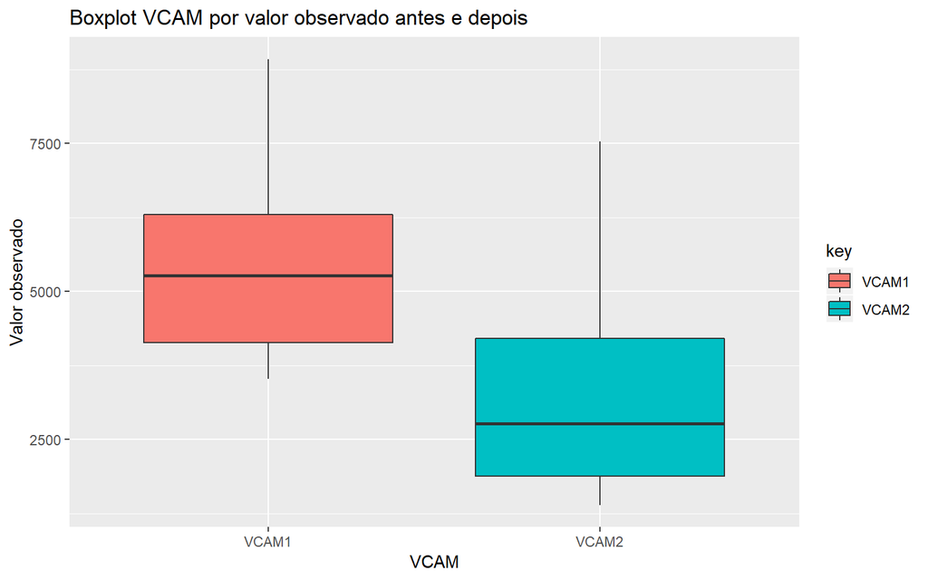

```r
base_vcam %>%
  gather() %>%
  ggplot(aes(x = key, y = value, fill = key)) +
  geom_boxplot() +
  labs(x = "VCAM", y = "Valor observado", title = "Boxplot VCAM por valor observado antes e depois")
```

Em geral, com base no gráfico, parece que houve uma redução no VCAM após o RETP.

### Teste de Hipóstese

```r
# Normalidade: VCAM antes
shapiro.test(base_vcam$VCAM1)
```

```
##
##  Shapiro-Wilk normality test
##
## data:  base_vcam$VCAM1
## W = 0.92911, p-value = 0.1046
```

Com base num nivel de significancia de 5%, não rejeitamos a hipótese de normalidade para a variavel.

```r
# Normalidade: VCAM depois
shapiro.test(base_vcam$VCAM2)
```

```
##
##  Shapiro-Wilk normality test
##
## data:  base_vcam$VCAM2
## W = 0.8418, p-value = 0.001939
```

Com base num nivel de significancia de 5%, rejeitamos a hipótese de normalidade para a variavel.

`Considerando normalidade mesmo não sendo normal`

#### Teste de Hipotese sobre a média para variâncias desconhecidas

H0: mu1 = mu2 H1: mu1 =/= mu2

```r
t.test(base_vcam$VCAM1, base_vcam$VCAM2, alternative = "two.sided", paired = T)
```

```
##
##  Paired t-test
##
## data:  base_vcam$VCAM1 and base_vcam$VCAM2
## t = 4.3695, df = 22, p-value = 0.0002447
## alternative hypothesis: true difference in means is not equal to 0
## 95 percent confidence interval:
##  1120.908 3146.157
## sample estimates:
## mean of the differences
##                2133.532
```

Com base num nível de significância de 5%, rejeitamos a hipótese nula, ou seja, há evidências de que a média da variável VCAM antes é diferente da média da variável VCAM depois.

Luiz Fernando, Lyncoln Sousa

02 de abril de 2019